# Experiment 11

**Aim**: WAP to implement K-means clustering algorithm.

# K-Means Clustering

K-means clustering is a type of unsupervised learning, which is used when you have unlabeled data (i.e., data without defined categories or groups). The goal of this algorithm is to find groups in the data, with the number of groups represented by the variable K. The algorithm works iteratively to assign each data point to one of K groups based on the features that are provided. Data points are clustered based on feature similarity.

The results of the K-means clustering algorithm are:

- The centroids of the K clusters, which can be used to label new data
- Labels for the training data (each data point is assigned to a single cluster)

## How the algorithm works

The K-means clustering algorithm uses two steps to group unlabeled data:

1. The algorithm first randomly assigns each observation to a cluster, with the total number of clusters being K.
2. Next, the algorithm iterates through two steps:
   - Reassign data points to the cluster whose centroid is closest.
   - Calculate new centroid of each cluster.

These two steps are repeated until the within cluster variation cannot be reduced any further. The within cluster variation is calculated as the sum of the euclidean distance between the data points and their respective cluster centroids.

```python
# importing the necessary packages
import numpy as np
import matplotlib.pyplot as plt
from sklearn.datasets import make_blobs
from sklearn.cluster import KMeans
```

```python
# Generate synthetic data
X, y = make_blobs(n_samples=300, centers=4, random_state=42)
```

```python
# Create a K-means model with the desired number of clusters (k)
k = 4
kmeans = KMeans(n_clusters=k)
```

```python
# Fit the model to the data and predict cluster labels
kmeans.fit(X)
cluster_labels = kmeans.labels_
```

```python
# Get the coordinates of cluster centers
cluster_centers = kmeans.cluster_centers_

# Visualize the data and cluster centers
plt.figure(figsize=(8, 6))
```

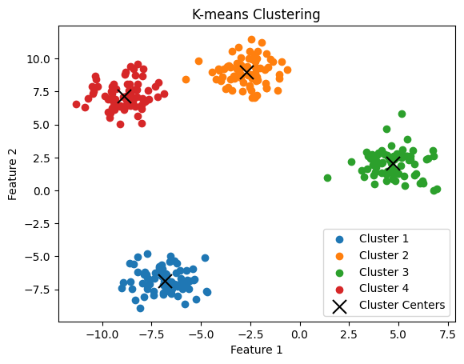

```python
# Plot data points with different colors for each cluster
for i in range(k):
    plt.scatter(X[cluster_labels == i, 0], X[cluster_labels == i, 1], label=f'Cluster {i+1}')

# Plot cluster centers
plt.scatter(cluster_centers[:, 0], cluster_centers[:, 1,], color='black', marker='x', s=150, label='Cluster Centers')

plt.xlabel('Feature 1')
plt.ylabel('Feature 2')
plt.title('K-means Clustering')
plt.legend()
plt.show()
```